# Report Group 4

[figure not shown]

Pierre Mulliez

### Contents Introduction Data analysis dates station_location heatmaps Data Cleaning Data Manipulation

Introduction

> ‘As part of the course **“Programming in R” at IE - HST**, we foster our newly learned skills by participating in a Kaggle competition. The problem requires us to do Exploratory Data Analysis, Data Cleaning and Manipulation and implement some sort of Machine Learning in R.’

The data can be found [here](https://www.kaggle.com/c/ams-2014-solar-energy-prediction-contest/overview)

## Including Plots - dates dependent

We have designed several plots to understand and include the right variable in our prediction, first we took a closer look at the stations pattern depending on the dates: # Here an overall visualization

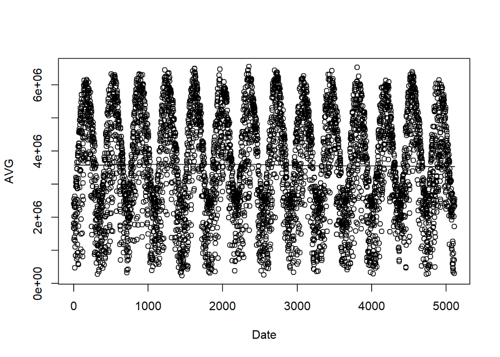

# Here visualizing by month - averaging the stations

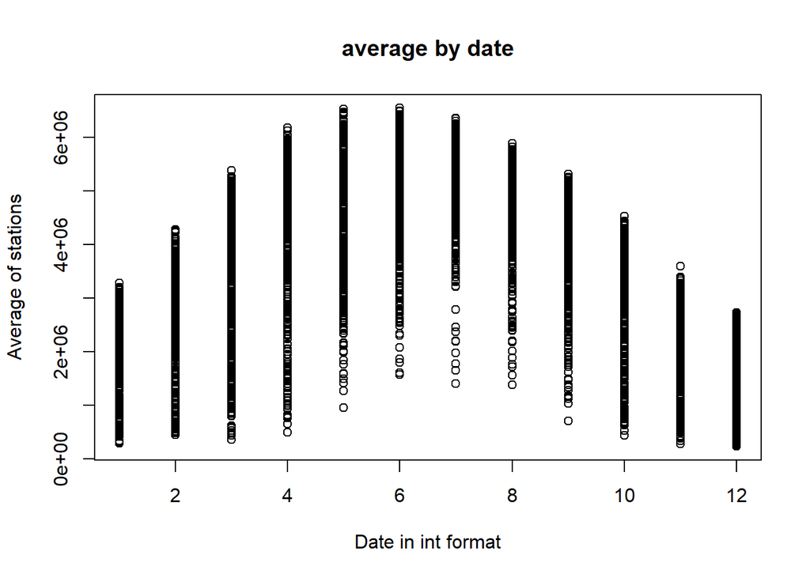

## Including Plots - station coordinates dependent

We have merged the station additional information file with the summary of each stations as a data table to produce a comprehensible comparison between the average of each stations accross all date, its altitude and coordinate # Here we are plotting each station to its location on a map with a color code corresponding to it’s altitude

```
## Google's Terms of Service: https://cloud.google.com/maps-platform/terms/.
```

```
## Using zoom = 7...
```

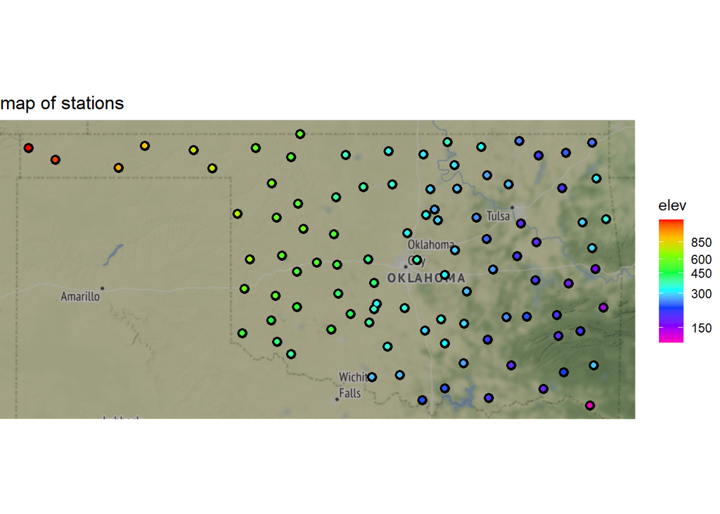

# Here we are plotting each station to its location on a map with a color code corresponding to it’s average over time

```
## Using zoom = 7...
```

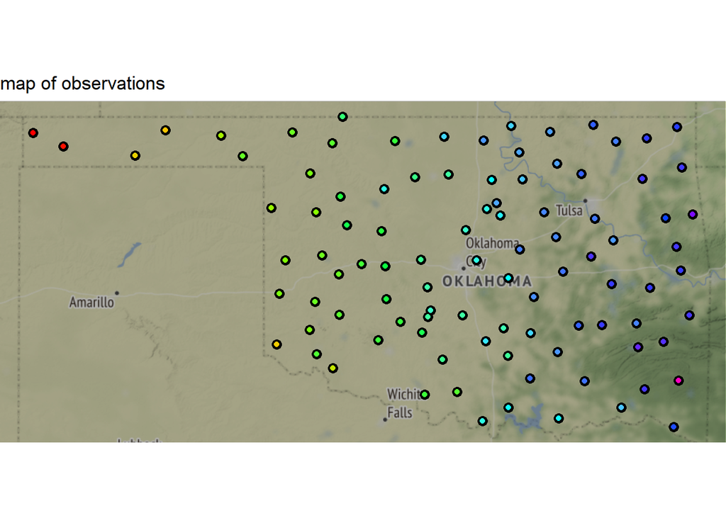

## Plot conclusion

- data is time variant with seasonnality pattern; higher osbervation are noticed in the summer month
- data is dependent upon location and elevation with higher / west stations recording higher observation

## Correlation amoungst station

following the analysis on their relative observation based on their location we thought we could establish some segmentation

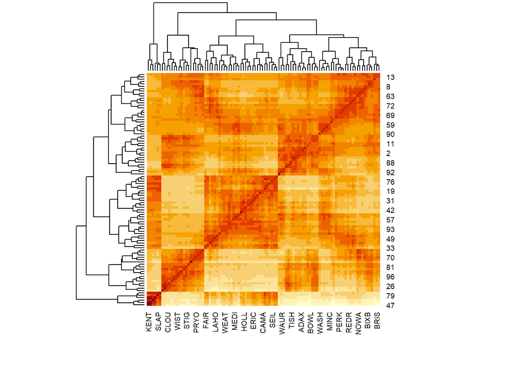

## More on stations; distributions

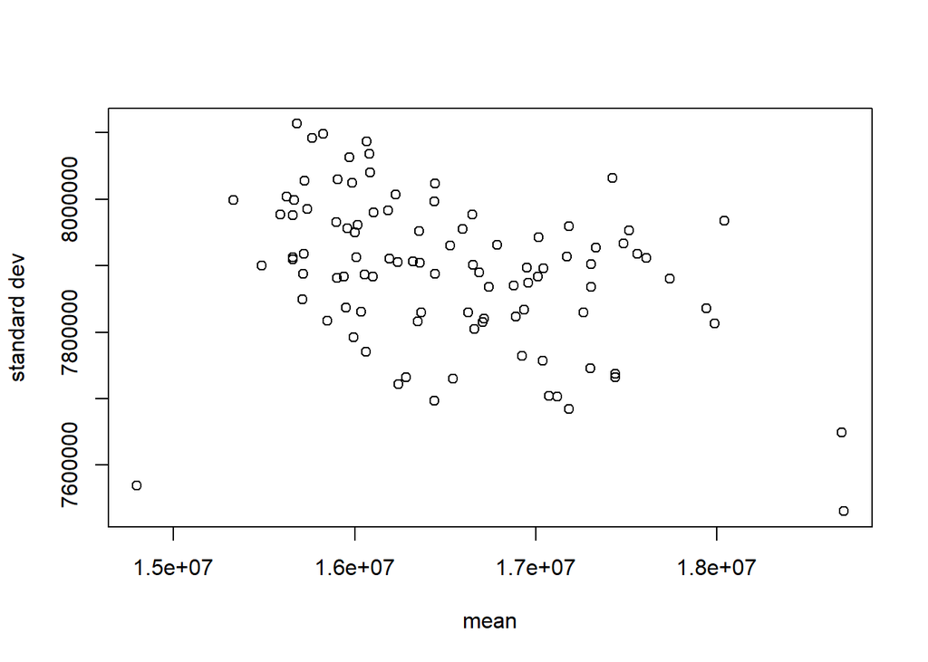

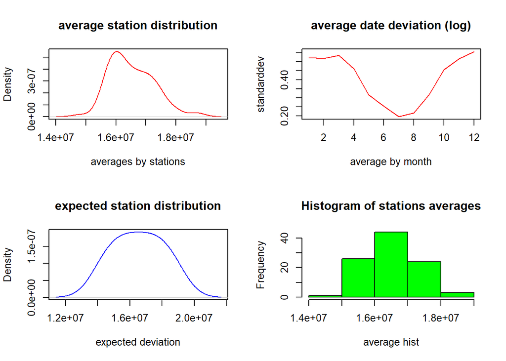

EDA